# Mô hình thống kê tuyến tính trên dữ liệu hình thái chim ruồi (BirdLife)

Dự đoán khối lượng cơ thể bằng OLS, Ridge, LASSO, PCR và phân tích phương sai nhiều nhân tố

Quang Nguyen - 25C23002

2026-07-28

# 1 Giới thiệu và câu hỏi nghiên cứu

## 1.1 Bối cảnh dữ liệu

Bộ dữ liệu `BirdLife.csv` gồm **366 quan sát và 37 biến**, mô tả 366 loài chim qua nhiều nhóm thông tin: định danh và phân loại loài (`Species1`, `Family1`, `Order1`, `Avibase.ID1`); cỡ mẫu và mức độ đầy đủ của phép đo (`Total.individuals`, `Female`, `Male`, `Unknown`, `Complete.measures`); nguồn và trạng thái suy luận dữ liệu (`Mass.Source`, `Mass.Refs.Other`, `Inference`, `Traits.inferred`, `Reference.species`); cũng như đặc điểm **hình thái học, sinh thái và phân bố địa lý**. Các biến địa lý gồm giới hạn và tâm phân bố (`Min.Latitude`, `Max.Latitude`, `Centroid.Latitude`, `Centroid.Longitude`) cùng kích thước vùng phân bố (`Range.Size`). `Sequence` là biến chỉ mục của bản ghi.

Trong phạm vi hai câu hỏi nghiên cứu của báo cáo, phân tích tập trung vào các biến hình thái gồm chiều dài mỏ (`Beak.Length_Culmen`, `Beak.Length_Nares`), bề rộng và độ sâu mỏ (`Beak.Width`, `Beak.Depth`), chiều dài chân (`Tarsus.Length`), chiều dài cánh (`Wing.Length`), khoảng cách Kipp (`Kipps.Distance`), lông cánh thứ cấp (`Secondary1`), **chỉ số Hand-Wing** (`Hand.Wing.Index`, viết tắt HWI), chiều dài đuôi (`Tail.Length`) và **khối lượng cơ thể** (`Mass`); cùng các biến sinh thái gồm môi trường sống (`Habitat`), mật độ sinh cảnh (`Habitat.Density`), tập tính di cư (`Migration`), bậc và ngách dinh dưỡng (`Trophic.Level`, `Trophic.Niche`) và lối sống chính (`Primary.Lifestyle`). Các nhóm biến còn lại chủ yếu được dùng để nhận diện quan sát, mô tả nguồn và chất lượng dữ liệu hoặc cung cấp bối cảnh bổ sung, nên không được đưa vào các mô hình chính của báo cáo.

## 1.2 Câu hỏi nghiên cứu

Dựa trên các nội dung phân tích được yêu cầu, báo cáo đề xuất 2 câu hỏi nghiên cứu với 1 cau được giải thích bằng các mô hình hồi quy và một câu còn lại được xem xét thông qua việc phân tích ANOVA nhiều nhân tố.

- *Ý nghĩa thống kê:* đây là bài toán hồi quy tuyến tính với hiện tượng đa cộng tuyến nghiêm trọng với bối cảnh điển hình để so sánh phương pháp hồi quy bình phương nhỏ nhất với các phương pháp chính quy như (Ridge, LASSO) và hồi quy trên thành phần chính (PCR)
- *Ý nghĩa sinh học:* quan hệ giữa kích thước cơ thể và các số đo hình thái là bài toán **allometry** (dị hình sinh trưởng) kinh điển. Do khối lượng khó đo trực tiếp trên tiêu bản bảo tàng, nên một mô hình dự đoán khối lượng từ số đo tuyến tính có giá trị thực tiễn để suy đoán khối lượng cho các mẫu vật thiếu cân.

- *Ý nghĩa thống kê:* mô hình phân tích phương sai hai nhân tố (Factorial ANOVA) với một biến phản hồi định lượng và hai nhân tố phân loại.
- *Ý nghĩa sinh học:* HWI phản ánh hình dạng cánh (cánh nhọn sẽ dẫn đến độ phát tán xa). Giả thuyết sinh thái là loài sống ở sinh cảnh thoáng/thưa cần bay xa hơn nên có HWI cao hơn loài sống trong rừng rậm.

# 2 Tiền xử lý dữ liệu

```r
if (!file.exists("BirdLife.csv")) {
  stop("Không tìm thấy BirdLife.csv trong working directory.", call. = FALSE)
}
raw <- read.csv("BirdLife.csv", stringsAsFactors = FALSE)
required_columns <- c(
  "Species1", "Avibase.ID1", "Family1", "Order1", "Mass", "Mass.Source",
  "Inference", "Total.individuals", "Complete.measures", "Range.Size",
  "Hand.Wing.Index", "Habitat", "Habitat.Density"
)
missing_columns <- setdiff(required_columns, names(raw))
if (length(missing_columns) > 0) {
  stop("Thiếu cột bắt buộc: ", paste(missing_columns, collapse = ", "), call. = FALSE)
}
if (anyDuplicated(raw$Species1) || anyDuplicated(raw$Avibase.ID1)) {
  stop("Species1 hoặc Avibase.ID1 không duy nhất; cần xác định lại đơn vị quan sát.",
       call. = FALSE)
}
dim_tab <- tibble::tibble(
  `Chỉ tiêu` = c("Số quan sát", "Số biến", "Số họ (Family1)",
                 "Số bộ (Order1)", "Số loài (Species1)"),
  `Giá trị` = c(nrow(raw), ncol(raw), dplyr::n_distinct(raw$Family1),
                dplyr::n_distinct(raw$Order1), dplyr::n_distinct(raw$Species1))
)
kb(dim_tab, caption = "Kích thước và cấu trúc cơ bản của bộ dữ liệu.")
```

Kích thước và cấu trúc cơ bản của bộ dữ liệu.

| Chỉ tiêu | Giá trị |
| --- | --- |
| Số quan sát | 366 |
| Số biến | 37 |
| Số họ (Family1) | 1 |
| Số bộ (Order1) | 1 |
| Số loài (Species1) | 366 |

**Nguồn dữ liệu.** Các tên biến và taxonomy cho thấy đây là tập con theo BirdLife của cơ sở dữ liệu [AVONET (Tobias và cộng sự, 2022)](https://doi.org/10.1111/ele.13898).

**Nhận xét.** Dữ liệu có 366 loài, mỗi loài là một quan sát duy nhất (366 loài phân biệt). Biến `Family1` và `Order1` chỉ nhận **một giá trị duy nhất** nên không mang thông tin phân biệt và sẽ bị loại.

## 2.1 Tiêu chí lựa chọn biến

Phần hồi quy dùng `log(Mass)` làm phản hồi, bảy số đo hình thái và `logRange` làm predictors. Các biến hằng số, định danh và metadata khuyết trên 90% bị loại. `Hand.Wing.Index` không được dùng làm predictor vì đây là chỉ số được tính từ Kipp’s distance và chiều dài cánh theo công thức $\text{HWI}=100\times\text{Kipps.Distance}/\text{Wing.Length}$. Do mô hình đã chứa các số đo cánh liên quan, bổ sung HWI sẽ tạo ra thông tin gần như trùng lặp và làm đa cộng tuyến nghiêm trọng hơn. HWI được giữ làm phản hồi cho ANOVA với hai nhân tố `Habitat` và `Habitat.Density`.

`Kipps.Distance` và `Secondary1` vẫn được mô tả trong EDA nhưng không cùng được đưa vào mô hình hồi quy chính với `Wing.Length`: ở mức trung bình loài, ba số đo này gần thỏa `Kipps.Distance = Wing.Length - Secondary1`. Giữ cả ba sẽ tạo đa cộng tuyến mang tính cấu trúc, không chỉ là tương quan sinh học.

## 2.2 Dữ liệu khuyết, trùng lặp và kiểu dữ liệu

```r
na_counts <- colSums(is.na(raw))
na_tab <- tibble::tibble(`Biến` = names(na_counts), `Số NA` = as.integer(na_counts)) |>
  filter(`Số NA` > 0) |>
  arrange(desc(`Số NA`)) |>
  mutate(`Tỷ lệ (%)` = round(100 * `Số NA` / nrow(raw), 1))
kb(na_tab, caption = "Các biến có giá trị khuyết.")
```

Các biến có giá trị khuyết.

| Biến | Số NA | Tỷ lệ (%) |
| --- | --- | --- |
| Traits.inferred | 360 | 98.4 |
| Reference.species | 360 | 98.4 |
| Mass.Refs.Other | 337 | 92.1 |
| Min.Latitude | 2 | 0.5 |
| Max.Latitude | 2 | 0.5 |
| Centroid.Latitude | 2 | 0.5 |
| Centroid.Longitude | 2 | 0.5 |
| Range.Size | 2 | 0.5 |
| Habitat | 1 | 0.3 |

```r
n_dup <- sum(duplicated(raw))
```

**Nhận xét.** Ba biến metadata (`Mass.Refs.Other`, `Traits.inferred`, `Reference.species`) khuyết trên 90% nên bị loại hoàn toàn. Các biến còn lại chỉ khuyết lẻ tẻ: `Habitat` (1 giá trị) và nhóm biến địa lý (`Range.Size`, các vĩ độ) khuyết 2 giá trị. Số quan sát **trùng lặp hoàn toàn** là 0. Vì số dòng bị mất dữ liệu rất nhỏ nên ta cũng có thể loại luôn những giá trị đó

```r
morph_vars <- c("Beak.Length_Culmen", "Beak.Length_Nares", "Beak.Width", "Beak.Depth",
                "Tarsus.Length", "Wing.Length", "Kipps.Distance", "Secondary1",
                "Tail.Length")
analysis_morph_vars <- setdiff(morph_vars, c("Kipps.Distance", "Secondary1"))

# Tập dữ liệu cho HỒI QUY: khối lượng + hình thái + vùng phân bố
reg_raw <- raw[, c("Species1", "Mass.Source", "Inference", "Total.individuals",
                   "Complete.measures", "Mass", morph_vars, "Range.Size")]
numeric_reg_vars <- c("Mass", morph_vars, "Range.Size")
if (any(!vapply(reg_raw[numeric_reg_vars], is.numeric, logical(1)))) {
  stop("Các biến định lượng của hồi quy phải có kiểu numeric.", call. = FALSE)
}
if (any(vapply(reg_raw[numeric_reg_vars], \(x) any(x <= 0, na.rm = TRUE), logical(1)))) {
  stop("Biến được log hoặc số đo hình thái có giá trị không dương.", call. = FALSE)
}
reg_complete <- reg_raw[complete.cases(reg_raw[numeric_reg_vars]), ]

# Phân tích chính loại khối lượng/trait được suy diễn hoặc khối lượng do mô hình khác tạo ra.
# Tập đầy đủ vẫn được giữ để báo cáo độ nhạy.
reg <- reg_complete |>
  filter(Inference == "NO",
         !Mass.Source %in% c("Inferred", "EltonTraits_Model"))
reg_sensitivity <- reg_complete

reg$logMass  <- log(reg$Mass)
reg$logRange <- log(reg$Range.Size)
reg_sensitivity$logMass <- log(reg_sensitivity$Mass)
reg_sensitivity$logRange <- log(reg_sensitivity$Range.Size)

# Log-transform các số đo hình thái lệch phải nặng (|skew| > 1)
skewed_morph_vars <- c("Beak.Length_Culmen", "Beak.Length_Nares", "Tail.Length")
log_skewed_vars <- paste0("log_", skewed_morph_vars)
reg[log_skewed_vars] <- lapply(reg[skewed_morph_vars], log)
reg_sensitivity[log_skewed_vars] <- lapply(reg_sensitivity[skewed_morph_vars], log)
model_morph_vars <- ifelse(analysis_morph_vars %in% skewed_morph_vars,
                           paste0("log_", analysis_morph_vars), analysis_morph_vars)
pred_vars <- c(model_morph_vars, "logRange")

# Tập dữ liệu cho ANOVA: HWI + hai nhân tố phân loại
anv <- raw[, c("Hand.Wing.Index", "Habitat", "Habitat.Density")]
anv <- na.omit(anv)
anv$Habitat        <- factor(anv$Habitat)
anv$Habitat.Density <- factor(anv$Habitat.Density,
                              levels = 1:3,
                              labels = c("Dày", "Bán mở", "Mở"))
if (anyNA(anv$Habitat.Density)) {
  stop("Habitat.Density có mã ngoài tập {1, 2, 3}.", call. = FALSE)
}

c(n_hoi_quy_chinh = nrow(reg), n_hoi_quy_day_du = nrow(reg_sensitivity),
  n_anova = nrow(anv))
```

```
##  n_hoi_quy_chinh n_hoi_quy_day_du          n_anova
##              354              364              365
```

**Nhận xét.** Sau khi loại dòng thiếu và các nguồn khối lượng/trait suy diễn, tập hồi quy chính còn 354 loài; tập đầy đủ để kiểm tra độ nhạy có 364 loài. Tập ANOVA còn 365 loài (mất 1 dòng thiếu `Habitat`). Ba số đo có |skew| > 1 được log-transform; các số đo còn lại giữ đơn vị gốc. `Habitat` và `Habitat.Density` được ép thành **factor** (mật độ 1/2/3 được gán nhãn Dày/Bán mở/Mở).

## 2.3 Giá trị ngoại lai

```r
flags <- sapply(reg[, morph_vars], iqr_flag)
outlier_tab <- tibble::tibble(
  `Chỉ tiêu` = c("% các điểm outlier được xác định",
                 "Số loài có ít nhất 1 biến bị gắn cờ",
                 "Biến bị xem là outlier nhiều nhất"),
  `Giá trị` = c(sprintf("%.2f %%", 100 * mean(flags)),
                sprintf("%d / %d (%.1f %%)", sum(rowSums(flags) > 0), nrow(reg),
                        100 * mean(rowSums(flags) > 0)),
                names(which.max(colSums(flags))))
)
kb(outlier_tab, caption = "Kết quả gắn cờ ngoại lai theo quy tắc IQR trên các biến số đo.")
```

Kết quả gắn cờ ngoại lai theo quy tắc IQR trên các biến số đo.

| Chỉ tiêu | Giá trị |
| --- | --- |
| % các điểm outlier được xác định | 1.88 % |
| Số loài có ít nhất 1 biến bị gắn cờ | 39 / 354 (11.0 %) |
| Biến bị xem là outlier nhiều nhất | Beak.Length_Nares |

Chúng ta đang sử dụng quy tắc IQR để đánh dáu điểm ngoại lai, điều này không chứng minh một giá trị là lỗi. Do đó chúng nên được **giữ lại tạm thời**. Ảnh hưởng của chúng sẽ được đánh giá qua chẩn đoán mô hình ở phần sau.

# 3 Khám phá và trực quan hóa dữ liệu

## 3.1 Thống kê mô tả

```r
desc <- psych::describe(reg[, c("Mass", morph_vars, "Range.Size")])[, c(
  "mean", "sd", "median", "min", "max", "skew", "kurtosis")]
kb(round(desc, 2), caption = "Thống kê mô tả các biến định lượng chính (đơn vị gốc).")
```

Thống kê mô tả các biến định lượng chính (đơn vị gốc).

|  | mean | sd | median | min | max | skew | kurtosis |
| --- | --- | --- | --- | --- | --- | --- | --- |
| Mass | 5.15 | 2.15 | 4.80 | 1.90 | 20.2 | 1.54 | 6.28 |
| Beak.Length_Culmen | 23.91 | 8.25 | 22.20 | 11.10 | 97.4 | 2.55 | 16.75 |
| Beak.Length_Nares | 18.92 | 7.51 | 17.55 | 6.70 | 87.2 | 2.72 | 18.42 |
| Beak.Width | 2.18 | 0.55 | 2.20 | 0.90 | 4.6 | 0.23 | 0.27 |
| Beak.Depth | 2.06 | 0.52 | 2.00 | 1.00 | 4.7 | 0.59 | 1.25 |
| Tarsus.Length | 5.15 | 1.16 | 5.10 | 2.50 | 9.3 | 0.51 | 0.20 |
| Wing.Length | 57.11 | 12.97 | 57.20 | 26.70 | 135.7 | 0.56 | 3.10 |
| Kipps.Distance | 35.98 | 7.92 | 35.95 | 13.00 | 85.9 | 0.65 | 4.00 |
| Secondary1 | 20.94 | 5.42 | 21.10 | 9.10 | 47.3 | 0.34 | 0.73 |
| Tail.Length | 40.54 | 14.05 | 37.80 | 13.50 | 105.6 | 1.36 | 2.68 |
| Range.Size | 765911.38 | 1770542.33 | 120185.93 | 8.09 | 11225568.6 | 3.53 | 13.14 |

**Nhận xét.** Không chỉ `Mass` lệch phải mạnh (skew = 1.54). `Beak.Length_Culmen` và `Beak.Length_Nares` còn lệch phải mạnh hơn, với skewness lần lượt 2.55 và 2.72; kurtosis rất cao (16.75 và 18.42) cho thấy đuôi phải dài. `Tail.Length` cũng lệch phải đáng kể (skew = 1.36). Ở bước mô tả, đây chỉ là đặc điểm phân phối và là tín hiệu để **cân nhắc** log-transform; chưa phải quyết định chọn dạng mô hình hay loại quan sát.

## 3.2 Đánh giá phép biến đổi log cho các biến lệch phải

```r
skew_vars <- c("Mass", skewed_morph_vars, "Range.Size")
logged_vars <- c("logMass", log_skewed_vars, "logRange")
skew_transform_tab <- tibble::tibble(
  `Biến` = skew_vars,
  `Skewness thang gốc` = vapply(skew_vars, \(v) desc[v, "skew"], numeric(1)),
  `Skewness sau log` = vapply(logged_vars, \(v) psych::describe(reg[[v]])$skew,
                              numeric(1))
)
kb(skew_transform_tab |> mutate(across(where(is.numeric), ~ round(.x, 2))),
   caption = "Skewness trước và sau log-transform của các biến lệch phải.")
```

Skewness trước và sau log-transform của các biến lệch phải.

| Biến | Skewness thang gốc | Skewness sau log |
| --- | --- | --- |
| Mass | 1.54 | 0.04 |
| Beak.Length_Culmen | 2.55 | 0.47 |
| Beak.Length_Nares | 2.72 | 0.34 |
| Tail.Length | 1.36 | 0.18 |
| Range.Size | 3.53 | -0.58 |

**Nhận xét.** Bảng này chỉ đánh giá tác dụng của log-transform lên **hình dạng phân phối**. Skewness giảm rõ đối với `Mass`, hai biến chiều dài mỏ, `Tail.Length` và `Range.Size`, nên các biến log tương ứng được xem là ứng viên. Riêng `Mass` là biến phản hồi; các biến còn lại là predictors, vốn không bắt buộc phải phân phối chuẩn. Vì vậy, quyết định predictors nào được log sẽ được kiểm tra bằng CV trên tập huấn luyện ở phần mô hình hóa, thay vì chỉ dựa vào skewness.

## 3.3 Tương quan giữa các biến hình thái và dấu hiệu đa cộng tuyến

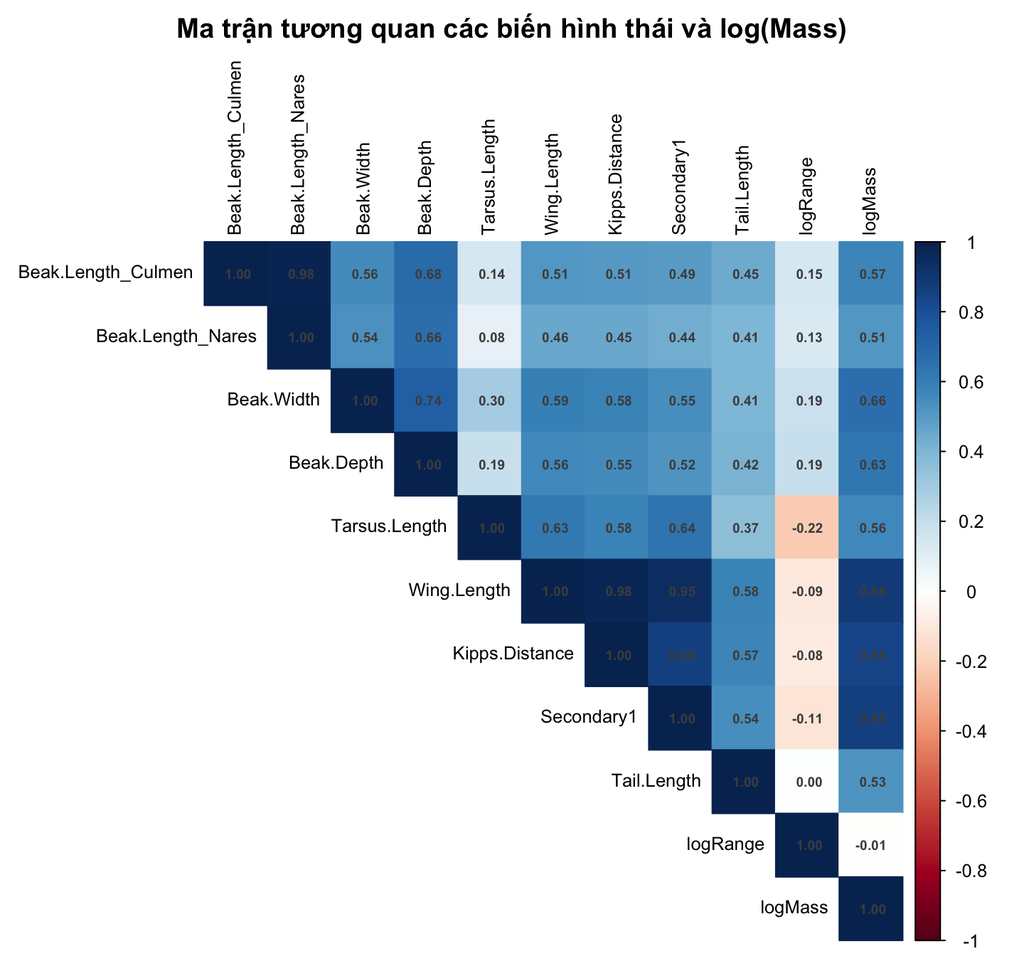

```r
R <- cor(reg[, c(morph_vars, "logRange", "logMass")])
corrplot::corrplot(R, method = "color", type = "upper", tl.col = "black",
                   tl.cex = 0.8, addCoef.col = "grey30", number.cex = 0.6,
                   title = "Ma trận tương quan các biến hình thái và log(Mass)",
                   mar = c(0, 0, 2, 0))
```

**Nhận xét.** Có nhiều cặp biến tương quan **rất cao**: `Wing.Length`–`Kipps.Distance` và `Beak.Length_Culmen`–`Beak.Length_Nares` đều xấp xỉ 0.98. Đây là **dấu hiệu đa cộng tuyến rõ rệt** cần kiểm tra sau khi xây dựng OLS; ở đây chưa diễn giải hệ số hay kết luận về VIF.

# 4 Xây dựng và đánh giá mô hình hồi quy

## 4.1 Chia dữ liệu và quy trình đánh giá thống nhất

Để **so sánh công bằng**, cả bốn mô hình sẽ được sử dụng **cùng một quy trình**: cùng phép chia 80% huấn luyện / 20% kiểm định, cùng một phân hoạch 10-fold cho việc thực hiện cross validation, và cùng bộ chỉ số RMSE / MAE / $R^2$ trên **cùng tập kiểm định**. Mọi tham số (trung bình–độ lệch chuẩn để chuẩn hóa, $\lambda$, số thành phần chính) chỉ được ước lượng trên tập huấn luyện rồi áp sang tập kiểm định, điều này là để giúp chúng ta tránh khỏi trường hợp data leakage.

**Data Leakage** là khi những thông tin có trong tập train bị lọt vào trong tập test, điều này sẽ giúp mô hình của chúng ta đưa ra các kết quả dự báo tốt hơn nhưng lại không áp dụng được ngoài đời thật bởi vì theo như quá trình sinh dữ liệu trong thực tế thì chúng ta sẽ không có được những thông tin bị lộ lọt này.

```r
set.seed(SEED)
n <- nrow(reg)
idx_train <- sample(seq_len(n), size = round(0.8 * n))

X_train_raw <- reg[idx_train, c(analysis_morph_vars, "logRange")]
X_train <- reg[idx_train, pred_vars]; X_val <- reg[-idx_train, pred_vars]
y_train <- reg$logMass[idx_train];    y_val <- reg$logMass[-idx_train]

set.seed(SEED)
foldid <- sample(rep(seq_len(10), length.out = nrow(X_train)))

xmat_train <- as.matrix(X_train); xmat_val <- as.matrix(X_val)

split_tab <- tibble::tibble(
  `Tập` = c("Huấn luyện", "Kiểm định"),
  `n` = c(length(y_train), length(y_val)),
  `Trung bình logMass` = c(mean(y_train), mean(y_val)),
  `Độ lệch chuẩn` = c(sd(y_train), sd(y_val))
)
kb(split_tab, digits = 3, caption = "Phân phối biến phản hồi giữa hai tập.")
```

Phân phối biến phản hồi giữa hai tập.

| Tập | n | Trung bình logMass | Độ lệch chuẩn |
| --- | --- | --- | --- |
| Huấn luyện | 283 | 1.557 | 0.396 |
| Kiểm định | 71 | 1.565 | 0.420 |

**Nhận xét.** Phép chia tạo $n_{train} = 283$ và $n_{val} = 71$. Trung bình và độ lệch chuẩn của `log(Mass)` gần nhau giữa hai tập, cho thấy lần chia không mất cân bằng. Lưu ý $n \gg p$ (283 quan sát so với 8 biến), nên OLS vẫn ước lượng được. Vấn đề của đa cộng tuyến ở đây là **độ ổn định/diễn giải** hệ số chứ không phải khả năng khớp của mô hình hồi quy.

### 4.1.1 Kiểm tra độ nhạy đối với dạng biến đổi predictors

Dạng biến đổi chính được **định trước**: log phản hồi, `Range.Size` và ba số đo lệch phải mạnh. Quyết định này không được thay đổi theo kết quả tập kiểm định. Bảng dưới dùng cùng 10 folds chỉ trên tập huấn luyện để kiểm tra xem kết quả có nhạy với ba đặc tả hợp lý hay không; đây không phải bước chọn đặc tả sau khi nhìn vào sai số nhỏ nhất.

```r
X_train_all_log <- as.data.frame(lapply(X_train_raw[, analysis_morph_vars], log))
X_train_all_log$logRange <- X_train_raw$logRange
cv_transform <- function(X) mean(vapply(seq_len(10), function(f) {
  tr <- foldid != f
  fit <- lm(y_train ~ ., data = data.frame(y_train, X)[tr, ])
  sqrt(mean((y_train[!tr] - predict(fit, X[!tr, ]))^2))
}, numeric(1)))
rmse_transform <- c(`Thang gốc` = cv_transform(X_train_raw),
                    `Log biến lệch nặng` = cv_transform(X_train),
                    `Log toàn bộ hình thái` = cv_transform(X_train_all_log))
kb(tibble::tibble(`Dạng mô hình` = names(rmse_transform),
                  `CV-RMSE` = round(rmse_transform, 4)),
   caption = "Chọn dạng biến đổi bằng CV trên tập huấn luyện.")
```

Chọn dạng biến đổi bằng CV trên tập huấn luyện.

| Dạng mô hình | CV-RMSE |
| --- | --- |
| Thang gốc | 0.1723 |
| Log biến lệch nặng | 0.1716 |
| Log toàn bộ hình thái | 0.1748 |

Báo cáo so sánh ba cách xử lý biến hình thái bằng RMSE từ cross-validation: giữ nguyên tất cả biến, chỉ lấy log các biến lệch phải mạnh và lấy log toàn bộ biến hình thái. Chênh lệch nhỏ giữa ba phương án được xem là độ nhạy của đặc tả, không phải bằng chứng chắc chắn rằng phương án có RMSE thấp nhất sẽ luôn tốt nhất. Mô hình chính giữ đặc tả đã định trước để tránh chọn preprocessing theo nhiễu của một lần chia folds. Do biến phản hồi là `log(Mass)`, hệ số của một predictor đã lấy log cho biết phần trăm thay đổi dự kiến của khối lượng khi predictor tăng 1%; còn với predictor chưa lấy log, hệ số cho biết khối lượng dự kiến thay đổi xấp xỉ $100\beta_j$% khi predictor tăng một đơn vị, trong điều kiện các biến khác không đổi.

## 4.2 Mô hình 1: Hồi quy tuyến tính OLS

**Lựa chọn biến.** Mô hình sử dụng 7 số đo hình thái để dự đoán khối lượng cơ thể vì những đặc điểm như kích thước mỏ, chân, cánh và đuôi có thể phản ánh kích thước chung của loài. Biến `Range.Size` biểu thị kích thước vùng phân bố và được biến đổi thành `logRange` để giảm độ lệch phải. Biến này được đưa vào như một biến địa lý bổ sung nhằm kiểm tra liệu phạm vi phân bố có cung cấp thêm thông tin cho việc dự đoán khối lượng sau khi đã xét các đặc điểm hình thái hay không. Mô hình OLS được sử dụng làm mô hình cơ sở để so sánh với Ridge, LASSO và PCR.

```r
ols <- lm(y_train ~ ., data = data.frame(y_train, X_train))
pred_ols <- predict(ols, newdata = X_val)
m_ols <- eval_metrics(y_val, pred_ols)

# Ablation: Range.Size có thực sự bổ sung khả năng dự báo ngoài hình thái?
ols_morph <- lm(y_train ~ ., data = data.frame(y_train, X_train[model_morph_vars]))
pred_ols_morph <- predict(ols_morph, newdata = X_val[model_morph_vars])
m_ols_morph <- eval_metrics(y_val, pred_ols_morph)
kb(tibble::tibble(
  `Đặc tả OLS` = c("Chỉ hình thái", "Hình thái + logRange"),
  RMSE = round(c(m_ols_morph["RMSE"], m_ols["RMSE"]), 4),
  R2 = round(c(m_ols_morph["R2"], m_ols["R2"]), 3)),
  caption = "Phân tích ablation cho đóng góp dự báo của logRange trên tập kiểm định.")
```

Phân tích ablation cho đóng góp dự báo của logRange trên tập kiểm định.

| Đặc tả OLS | RMSE | R2 |
| --- | --- | --- |
| Chỉ hình thái | 0.1596 | 0.854 |
| Hình thái + logRange | 0.1604 | 0.852 |

```r
# Độ nhạy đối với chính sách loại nguồn suy diễn/mô hình hóa, dùng 10-fold CV cố định.
source_cv_rmse <- function(dat) {
  set.seed(SEED)
  fo <- sample(rep(seq_len(10), length.out = nrow(dat)))
  err <- unlist(lapply(seq_len(10), function(f) {
    tr <- fo != f
    fit <- lm(logMass ~ ., data = dat[tr, c("logMass", pred_vars)])
    dat$logMass[!tr] - predict(fit, newdata = dat[!tr, pred_vars])
  }))
  sqrt(mean(err^2))
}
source_sensitivity <- tibble::tibble(
  `Chính sách nguồn dữ liệu` = c("Loại trait/khối lượng suy diễn (chính)",
                                 "Giữ toàn bộ dòng đầy đủ"),
  n = c(nrow(reg), nrow(reg_sensitivity)),
  `CV-RMSE OLS` = round(c(source_cv_rmse(reg),
                          source_cv_rmse(reg_sensitivity)), 4)
)
kb(source_sensitivity,
   caption = "Độ nhạy của OLS với chính sách giữ/loại nguồn trait và khối lượng.")
```

Độ nhạy của OLS với chính sách giữ/loại nguồn trait và khối lượng.

| Chính sách nguồn dữ liệu | n | CV-RMSE OLS |
| --- | --- | --- |
| Loại trait/khối lượng suy diễn (chính) | 354 | 0.1724 |
| Giữ toàn bộ dòng đầy đủ | 364 | 0.1711 |

`logRange` chỉ được xem là hữu ích cho bài toán triển khai nếu thông tin vùng phân bố thực sự có sẵn tại thời điểm cần dự đoán khối lượng. Bảng ablation tách đóng góp của biến địa lý khỏi khả năng dự báo bằng hình thái.

### 4.2.1 Đa cộng tuyến trong OLS

```r
vif_tab <- tibble::tibble(
  `Biến` = names(car::vif(ols)),
  `VIF` = round(as.numeric(car::vif(ols)), 1)
) |> arrange(desc(VIF))
kb(vif_tab, caption = "Hệ số phóng đại phương sai của OLS trên tập huấn luyện.")
```

Hệ số phóng đại phương sai của OLS trên tập huấn luyện.

| Biến | VIF |
| --- | --- |
| log_Beak.Length_Culmen | 29.2 |
| log_Beak.Length_Nares | 27.5 |
| Wing.Length | 3.2 |
| Beak.Depth | 3.0 |
| Beak.Width | 2.7 |
| Tarsus.Length | 1.9 |
| log_Tail.Length | 1.8 |
| logRange | 1.3 |

VIF lớn nhất là 29, thuộc nhóm hai cách đo chiều dài mỏ. Việc bỏ hai số đo cánh gần dẫn xuất đã loại nguồn cộng tuyến cấu trúc lớn nhất, nhưng tương quan còn lại vẫn làm hệ số OLS riêng lẻ kém ổn định và tạo cơ sở so sánh với Ridge, LASSO và PCR.

### 4.2.2 Kiểm tra giả định của OLS

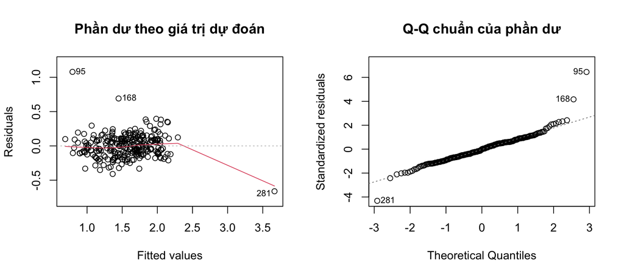

```r
par(mfrow = c(1, 2))
plot(ols, which = 1, caption = "")
title("Phần dư theo giá trị dự đoán")
plot(ols, which = 2, caption = "")
title("Q-Q chuẩn của phần dư")
```

```r
par(mfrow = c(1, 1))

bp <- lmtest::bptest(ols)
sw <- shapiro.test(residuals(ols))
reset <- lmtest::resettest(ols, power = 2:3, type = "fitted")
cook_ols <- cooks.distance(ols)
influential_ols <- cook_ols > 4 / nobs(ols)
ols_trim <- update(ols, subset = !influential_ols)
pred_ols_trim <- predict(ols_trim, newdata = X_val)
m_ols_trim <- eval_metrics(y_val, pred_ols_trim)
assum_tab <- tibble::tibble(
  `Giả định` = c("Phương sai đồng nhất (Breusch-Pagan)",
                 "Phần dư chuẩn (Shapiro-Wilk)",
                 "Đặc tả tuyến tính (RESET)"),
  `p-value` = c(fmt_p(bp$p.value), fmt_p(sw$p.value), fmt_p(reset$p.value))
)
kb(assum_tab, caption = "Kiểm định giả định của mô hình OLS.")
```

Kiểm định giả định của mô hình OLS.

| Giả định | p-value |
| --- | --- |
| Phương sai đồng nhất (Breusch-Pagan) | 0.582 |
| Phần dư chuẩn (Shapiro-Wilk) | < 0.001 |
| Đặc tả tuyến tính (RESET) | < 0.001 |

```r
kb(tibble::tibble(
  `Chẩn đoán độ nhạy` = c("Số điểm Cook > 4/n",
                          "RMSE kiểm định — mô hình đầy đủ",
                          "RMSE kiểm định — bỏ điểm Cook cao khỏi train"),
  `Kết quả` = c(sum(influential_ols),
                round(m_ols["RMSE"], 4), round(m_ols_trim["RMSE"], 4))),
  caption = "Độ nhạy của OLS với các quan sát ảnh hưởng mạnh.")
```

Độ nhạy của OLS với các quan sát ảnh hưởng mạnh.

| Chẩn đoán độ nhạy | Kết quả |
| --- | --- |
| Số điểm Cook > 4/n | 15.0000 |
| RMSE kiểm định — mô hình đầy đủ | 0.1604 |
| RMSE kiểm định — bỏ điểm Cook cao khỏi train | 0.1654 |

**Nhận xét.**

**Về tính tuyến tính:** Trên biểu đồ phần dư theo giá trị dự đoán, phần dư nhìn chung phân bố quanh đường 0 nhưng đường làm trơn cong xuống ở các giá trị dự đoán lớn. Kết hợp với RESET bên dưới, đây là dấu hiệu đặc tả tuyến tính hiện tại chưa nắm bắt hết cấu trúc, đặc biệt ở nhóm loài có khối lượng lớn.

**Về phương sai:** Kiểm định Breusch-Pagan cho p = 0.582, nên chưa có bằng chứng để bác bỏ giả định phương sai đồng nhất.

**Về phân phối phần dư:** Shapiro-Wilk bác bỏ mạnh giả định phần dư chuẩn (p < 0.001). Một vài loài có khối lượng thực tế lệch khá xa dự đoán, làm phân phối phần dư có đuôi nặng. Phần diễn giải hệ số bên dưới báo cáo thêm **sai số chuẩn robust HC3** để giảm nhạy với phương sai không đồng nhất. HC3 không sửa được sai đặc tả, ngoại lai hay phụ thuộc phát sinh loài, nên p-value vẫn chỉ mang tính thăm dò.

**Về đặc tả và điểm ảnh hưởng:** RESET có p = < 0.001, nên mô hình tuyến tính hiện tại có dấu hiệu bỏ sót phi tuyến hoặc thành phần cấu trúc. Có 15 điểm vượt Cook > 4/n. Phân tích bỏ các điểm này chỉ là kiểm tra độ nhạy, không phải quy tắc tự động xóa dữ liệu; sự thay đổi hệ số và RMSE cần được xem trước khi diễn giải.

**Về tính độc lập:** Durbin-Watson không được dùng vì dữ liệu loài không có thứ tự thời gian. Điều đáng quan tâm là các loài có họ hàng gần có thể tương quan với nhau. Khi chưa có cây phát sinh loài, p-value của hệ số chỉ mang tính thăm dò; vấn đề này được nhắc lại ở phần hạn chế.

### 4.2.3 Diễn giải hệ số OLS (kèm sai số chuẩn robust HC3)

```r
# Chuẩn hóa để so sánh độ lớn ảnh hưởng.
# Xếp hạng theo |hệ số| (không phải theo giá trị có dấu), vì câu hỏi ở đây là
# "biến nào ảnh hưởng mạnh nhất", còn dấu được đọc riêng ở cột kế bên.
std <- scale(X_train)
ols_std <- lm(y_train ~ ., data = data.frame(y_train, as.data.frame(std)))
cs <- coef(ols_std)[-1]
coef_std <- cs[order(abs(cs), decreasing = TRUE)]

# Sai số chuẩn robust HC3 trên hệ số thang gốc
rob <- lmtest::coeftest(ols, vcov. = sandwich::vcovHC(ols, type = "HC3"))
rob_tab <- tibble::tibble(
  `Biến` = rownames(rob)[-1],
  `Hệ số (thang gốc)` = round(rob[-1, "Estimate"], 4),
  `SE robust (HC3)` = round(rob[-1, "Std. Error"], 4),
  `p-value` = vapply(rob[-1, "Pr(>|t|)"], fmt_p, character(1)))
kb(tibble::tibble(`Biến` = names(coef_std),
                  `Hệ số chuẩn hóa` = round(coef_std, 3),
                  `|Hệ số|` = round(abs(coef_std), 3)),
   caption = "Hệ số OLS trên biến đã chuẩn hóa, xếp theo độ lớn ảnh hưởng.")
```

Hệ số OLS trên biến đã chuẩn hóa, xếp theo độ lớn ảnh hưởng.

| Biến | Hệ số chuẩn hóa | &#124;Hệ số&#124; |
| --- | --- | --- |
| Wing.Length | 0.261 | 0.261 |
| log_Beak.Length_Culmen | 0.217 | 0.217 |
| log_Beak.Length_Nares | -0.167 | 0.167 |
| Beak.Width | 0.050 | 0.050 |
| Beak.Depth | 0.031 | 0.031 |
| Tarsus.Length | 0.026 | 0.026 |
| log_Tail.Length | -0.019 | 0.019 |
| logRange | 0.005 | 0.005 |

```r
kb(rob_tab, caption = "Hệ số OLS thang gốc với sai số chuẩn robust HC3.")
```

Hệ số OLS thang gốc với sai số chuẩn robust HC3.

| Biến | Hệ số (thang gốc) | SE robust (HC3) | p-value |
| --- | --- | --- | --- |
| log_Beak.Length_Culmen | 0.7161 | 0.2186 | 0.001 |
| log_Beak.Length_Nares | -0.4762 | 0.1757 | 0.007 |
| Beak.Width | 0.0900 | 0.0335 | 0.008 |
| Beak.Depth | 0.0590 | 0.0329 | 0.074 |
| Tarsus.Length | 0.0236 | 0.0152 | 0.123 |
| Wing.Length | 0.0207 | 0.0026 | < 0.001 |
| log_Tail.Length | -0.0608 | 0.0485 | 0.211 |
| logRange | 0.0023 | 0.0066 | 0.727 |

**Nhận xét.**

**Khi so sánh các hệ số đã chuẩn hóa:** Ba hệ số có độ lớn cao nhất thuộc về Wing.Length (|β| = 0.261), log_Beak.Length_Culmen (0.217) và log_Beak.Length_Nares (0.167). Tuy nhiên, cả ba đều thuộc những nhóm biến tương quan rất mạnh. Vì các biến này cung cấp thông tin gần giống nhau, OLS khó tách riêng đóng góp của từng biến. Do đó, hệ số lớn chưa đủ để kết luận một đặc điểm quan trọng hơn về mặt sinh học. Các hệ số của hai cách đo chiều dài mỏ vẫn có thể mang dấu hoặc độ lớn nhạy với mẫu huấn luyện, vì chúng cung cấp thông tin gần trùng nhau.

**Ảnh hưởng của đa cộng tuyến:** Việc bỏ hai số đo cánh gần dẫn xuất làm giảm đa cộng tuyến mang tính cấu trúc, nhưng hai biến chiều dài mỏ vẫn tương quan mạnh. Vì vậy, mô hình có thể dự báo tốt trong khi hệ số riêng còn thiếu ổn định. Ridge, LASSO và PCR được sử dụng tiếp theo để xử lý hạn chế đó theo những cách khác nhau.

## 4.3 Mô hình 2: Ridge Regression

**Cách mô hình hoạt động.** Ridge giữ lại toàn bộ biến nhưng kéo các hệ số về gần 0 để chúng bớt nhạy với những thay đổi nhỏ trong dữ liệu. Vì vậy, Ridge phù hợp khi các biến dự báo tương quan mạnh và ta không muốn loại biến nào. Về kỹ thuật, đây là dạng phạt $L_2$ với $\alpha = 0$.

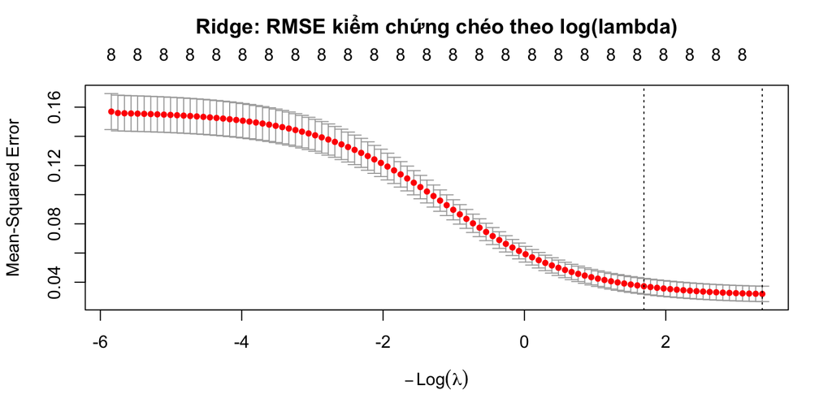

```r
set.seed(SEED)
cv_ridge <- glmnet::cv.glmnet(xmat_train, y_train, alpha = 0, foldid = foldid)
pred_ridge <- as.numeric(predict(cv_ridge, s = "lambda.min", newx = xmat_val))
m_ridge <- eval_metrics(y_val, pred_ridge)
plot(cv_ridge)
title("Ridge: RMSE kiểm chứng chéo theo log(lambda)", line = 2.5)
```

**Lựa chọn mức phạt.** Tham số $\lambda$ quyết định mức độ kéo các hệ số về 0. Kiểm chứng chéo chọn $\lambda_{min} = 0.0346$, là giá trị cho RMSE trung bình nhỏ nhất trên tập huấn luyện.

**Kết quả dự báo.** Trên tập kiểm định, Ridge đạt RMSE = 0.1576 và $R^2 = 0.857$. Kết quả này gần tương đương OLS, nên Ridge chưa cải thiện đáng kể độ chính xác dự báo trong dữ liệu này. Lợi ích chính của Ridge là làm các hệ số bớt nhạy khi nhiều biến cung cấp thông tin gần giống nhau.

## 4.4 Mô hình 3: LASSO Regression

**Cách mô hình hoạt động.** LASSO có thể kéo một số hệ số về đúng 0. Những biến có hệ số bằng 0 được loại khỏi mô hình, vì vậy LASSO vừa xây dựng mô hình dự báo vừa thực hiện chọn biến tự động. Về kỹ thuật, đây là dạng phạt $L_1$ với $\alpha = 1$.

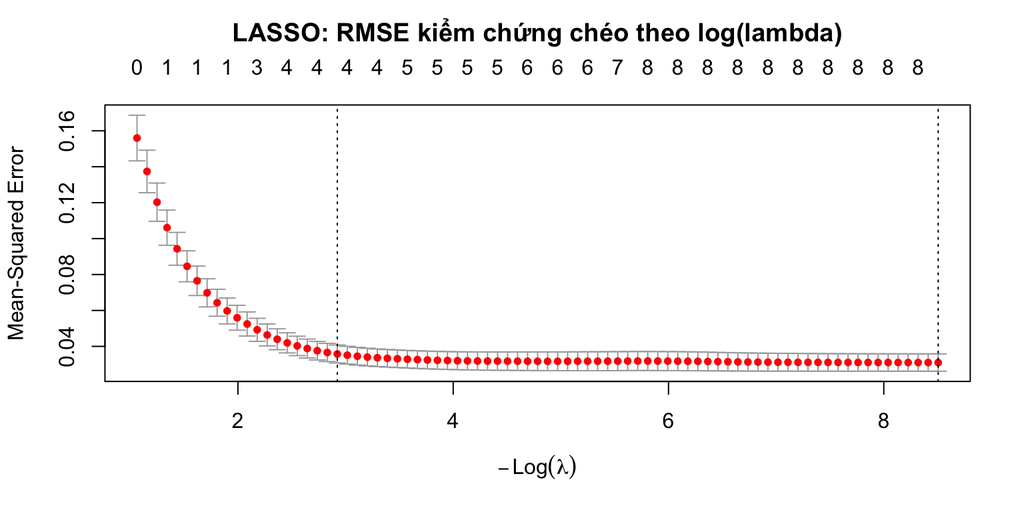

```r
set.seed(SEED)
cv_lasso <- glmnet::cv.glmnet(xmat_train, y_train, alpha = 1, foldid = foldid)
pred_lasso <- as.numeric(predict(cv_lasso, s = "lambda.1se", newx = xmat_val))
m_lasso <- eval_metrics(y_val, pred_lasso)
plot(cv_lasso)
title("LASSO: RMSE kiểm chứng chéo theo log(lambda)", line = 2.5)
```

```r
co <- as.matrix(coef(cv_lasso, s = "lambda.1se"))
kept <- co[co[, 1] != 0, , drop = FALSE]
kb(tibble::tibble(`Biến giữ lại` = rownames(kept), `Hệ số` = round(kept[, 1], 4)),
   caption = "Các biến được LASSO giữ lại tại lambda.1se.")
```

Các biến được LASSO giữ lại tại lambda.1se.

| Biến giữ lại | Hệ số |
| --- | --- |
| (Intercept) | -0.0173 |
| log_Beak.Length_Culmen | 0.0804 |
| Beak.Width | 0.0556 |
| Beak.Depth | 0.0252 |
| Wing.Length | 0.0202 |

**Lựa chọn mức phạt.** Báo cáo dùng quy tắc one-sigma và chọn $\lambda_{1se}$. Quy tắc này chấp nhận sai số kiểm chứng chéo cao hơn mức thấp nhất một chút để ưu tiên mô hình đơn giản hơn.

**Các biến được giữ lại.** LASSO giữ 4 biến: log_Beak.Length_Culmen, Beak.Width, Beak.Depth, Wing.Length. Hai biến chiều dài mỏ tương quan rất mạnh ($r \approx 0.98$), nên việc LASSO giữ một hoặc cả hai phụ thuộc vào mức phạt và mẫu huấn luyện. Tiền tố `log_` cho biết biến đã được lấy log.

Danh sách này không có nghĩa rằng các biến bị loại không quan trọng về mặt sinh học. Khi hai biến cung cấp thông tin gần như giống nhau, biến được giữ lại có thể thay đổi theo cách chia dữ liệu và giá trị $\lambda$.

**Kết quả dự báo.** LASSO có RMSE kiểm định = 0.1689 và $R^2 = 0.836$. So với OLS và Ridge, mô hình đơn giản hơn nhiều nhưng độ chính xác dự báo giảm nhẹ. Đây là sự đánh đổi giữa số lượng biến và khả năng dự báo.

## 4.5 Mô hình 4: Principal Component Regression (PCR)

**Cách mô hình hoạt động.** PCR gộp các biến dự báo tương quan thành một số biến tổng hợp gọi là **thành phần chính**. Các thành phần này không tương quan với nhau, nên mô hình tránh được đa cộng tuyến. Sau đó, PCR dùng $k$ thành phần được chọn để dự đoán `log(Mass)`, thay vì dùng trực tiếp toàn bộ biến ban đầu.

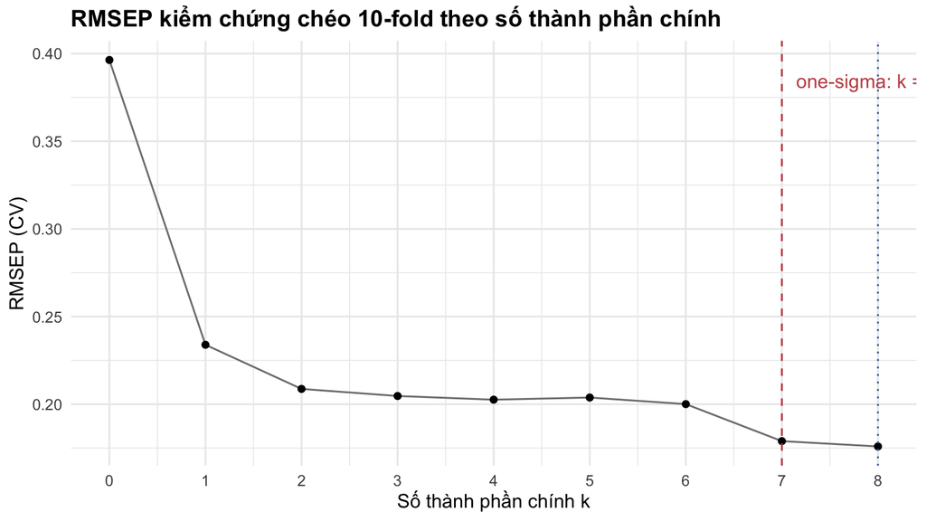

```r
set.seed(SEED)
df_train <- data.frame(y = y_train, X_train)
pcr_fit <- pls::pcr(y ~ ., data = df_train, scale = TRUE, center = TRUE,
                    validation = "CV",
                    segments = split(seq_len(nrow(X_train)), foldid))
rmsep_cv <- pls::RMSEP(pcr_fit, estimate = "CV")$val[1, 1, ]
k_min <- which.min(rmsep_cv) - 1
k_os  <- pls::selectNcomp(pcr_fit, method = "onesigma")
pve <- cumsum(pls::explvar(pcr_fit)) / 100

df_rmsep <- tibble::tibble(k = 0:(length(rmsep_cv) - 1), RMSEP = as.numeric(rmsep_cv))
ggplot(df_rmsep, aes(k, RMSEP)) +
  geom_line(color = "grey50") + geom_point() +
  geom_vline(xintercept = k_os, linetype = "dashed", color = "#C44E52") +
  geom_vline(xintercept = k_min, linetype = "dotted", color = "#4C72B0") +
  annotate("text", x = k_os, y = max(df_rmsep$RMSEP) * 0.97,
           label = paste("one-sigma: k =", k_os), color = "#C44E52", hjust = -0.1) +
  scale_x_continuous(breaks = 0:length(rmsep_cv)) +
  labs(title = "RMSEP kiểm chứng chéo 10-fold theo số thành phần chính",
       x = "Số thành phần chính k", y = "RMSEP (CV)")
```

```r
pred_pcr <- as.numeric(predict(pcr_fit, newdata = X_val, ncomp = k_os))
m_pcr <- eval_metrics(y_val, pred_pcr)
kb(tibble::tibble(
  `Quy tắc chọn k` = c("Cực tiểu RMSEP", "One-sigma (đã chọn)"),
  `k` = c(k_min, k_os),
  `% phương sai X giữ lại` = round(100 * c(pve[k_min], pve[k_os]), 1),
  `RMSEP (CV)` = round(c(rmsep_cv[k_min + 1], rmsep_cv[k_os + 1]), 4)),
  caption = "Lựa chọn số thành phần chính cho PCR.")
```

Lựa chọn số thành phần chính cho PCR.

| Quy tắc chọn k | k | % phương sai X giữ lại | RMSEP (CV) |
| --- | --- | --- | --- |
| Cực tiểu RMSEP | 8 | 100.0 | 0.1759 |
| One-sigma (đã chọn) | 7 | 99.8 | 0.1790 |

**Lựa chọn số thành phần.** RMSEP kiểm chứng chéo nhỏ nhất tại $k = 8$. Tuy nhiên, phương án này giữ gần như toàn bộ thông tin và khiến PCR gần giống OLS.

```r
pca <- prcomp(X_train, center = TRUE, scale. = TRUE)
kb(round(pca$rotation[, 1:2], 2),
   caption = "Vector tải (loadings) của 2 thành phần chính đầu.")
```

Vector tải (loadings) của 2 thành phần chính đầu.

|  | PC1 | PC2 |
| --- | --- | --- |
| log_Beak.Length_Culmen | -0.43 | -0.22 |
| log_Beak.Length_Nares | -0.42 | -0.25 |
| Beak.Width | -0.40 | -0.08 |
| Beak.Depth | -0.41 | -0.18 |
| Tarsus.Length | -0.20 | 0.61 |
| Wing.Length | -0.38 | 0.35 |
| log_Tail.Length | -0.34 | 0.23 |
| logRange | -0.05 | -0.55 |

**Diễn giải PC1.** Các số đo hình thái có tải cùng chiều và độ lớn khá tương đồng trên PC1. Điều này cho thấy PC1 chủ yếu phản ánh xu hướng kích thước hình thái chung: loài có giá trị cao ở một số đo thường cũng cao ở các số đo khác. Riêng PC1 giải thích 52.5% biến thiên của các biến dự báo, nên đây là xu hướng chung nổi bật nhất và cũng là một nguồn của đa cộng tuyến.

**Diễn giải PC2.** PC2 chủ yếu thể hiện sự tương phản giữa nhóm biến về mỏ với nhóm biến về cánh và chân; `logRange` cũng đóng góp đáng kể vào thành phần này. Vì vậy, PC2 có thể được hiểu thận trọng như một trục kết hợp giữa hình dạng cơ thể và phạm vi phân bố, thay vì một đặc điểm sinh học đơn lẻ.

Dấu của các tải có thể đảo ngược mà không làm thay đổi ý nghĩa của thành phần chính. Vì vậy, khi diễn giải PC1 và PC2, điều quan trọng là các biến thay đổi cùng chiều hay ngược chiều với nhau, không phải bản thân dấu âm hay dấu dương.

## 4.6 So sánh bốn mô hình hồi quy

Phần này so sánh bốn mô hình theo ba khía cạnh: độ ổn định của kết quả đánh giá, sai số dự đoán theo gram và mức độ đơn giản của mô hình. Các chỉ số chính được gộp vào một bảng ở cuối mục để người đọc dễ đối chiếu.

### 4.6.1 Đánh giá bằng kiểm chứng chéo lặp lại (repeated CV)

**Vì sao cần repeated CV?** Một lần chia dữ liệu theo tỷ lệ 80/20 chỉ có khoảng 71 quan sát trong tập kiểm định. Kết quả vì thế có thể thay đổi tùy vào những quan sát được đưa vào mỗi tập.

Để đánh giá ổn định hơn, báo cáo thực hiện kiểm chứng chéo 10-fold và lặp lại 5 lần, tạo ra 50 lần đánh giá. Trong mỗi lần, các tham số của Ridge, LASSO và PCR được chọn lại chỉ từ dữ liệu huấn luyện. Sau đó, báo cáo tính RMSE trung bình và độ lệch chuẩn của RMSE. RMSE càng thấp thì sai số dự báo càng nhỏ.

```r
set.seed(SEED)
reps <- 5; K <- 10
rep_res <- matrix(NA_real_, reps * K, 4,
                  dimnames = list(NULL, c("OLS", "Ridge", "LASSO", "PCR")))
row_i <- 0
Xall <- reg[, pred_vars]; yall <- reg$logMass
for (rp in seq_len(reps)) {
  set.seed(100 + rp)
  fo <- sample(rep(seq_len(K), length.out = nrow(Xall)))
  for (k in seq_len(K)) {
    row_i <- row_i + 1; tri <- fo != k
    Xa <- Xall[tri, ]; Xb <- Xall[!tri, ]; ya <- yall[tri]; yb <- yall[!tri]
    ma <- as.matrix(Xa); mb <- as.matrix(Xb)
    o <- lm(ya ~ ., data = data.frame(ya, Xa))
    rep_res[row_i, "OLS"] <- sqrt(mean((yb - predict(o, Xb))^2))
    cr <- glmnet::cv.glmnet(ma, ya, alpha = 0)
    rep_res[row_i, "Ridge"] <- sqrt(mean((yb - predict(cr, s = "lambda.min", newx = mb))^2))
    cl <- glmnet::cv.glmnet(ma, ya, alpha = 1)
    rep_res[row_i, "LASSO"] <- sqrt(mean((yb - predict(cl, s = "lambda.1se", newx = mb))^2))
    pf <- pls::pcr(ya ~ ., data = data.frame(ya, Xa), scale = TRUE, validation = "CV")
    ncp <- tryCatch(pls::selectNcomp(pf, method = "onesigma"), error = function(e) 1L)
    if (ncp < 1) ncp <- 1L
    rep_res[row_i, "PCR"] <- sqrt(mean((yb - as.numeric(predict(pf, newdata = Xb, ncomp = ncp)))^2))
  }
}
kb(tibble::tibble(
  `Mô hình` = colnames(rep_res),
  `RMSE trung bình` = round(colMeans(rep_res), 4),
  `Độ lệch chuẩn` = round(apply(rep_res, 2, sd), 4)),
  caption = "Repeated 5×10-fold CV (RMSE thang log, tuning lồng trong mỗi fold).")
```

Repeated 5×10-fold CV (RMSE thang log, tuning lồng trong mỗi fold).

| Mô hình | RMSE trung bình | Độ lệch chuẩn |
| --- | --- | --- |
| OLS | 0.1677 | 0.0350 |
| Ridge | 0.1713 | 0.0331 |
| LASSO | 0.1818 | 0.0294 |
| PCR | 0.1710 | 0.0357 |

**Kết quả.** RMSE trung bình của OLS và Ridge gần như bằng nhau: 0.1677 và 0.1713. Mức chênh lệch này nhỏ hơn nhiều so với độ dao động của RMSE giữa các fold, khoảng 0.034. Vì vậy, kết quả không cho thấy OLS hay Ridge có lợi thế dự báo rõ rệt so với nhau.

### 4.6.2 Sai số quy đổi về gram

**Vì sao cần quy đổi?** Các mô hình dự đoán `log(Mass)`, nên RMSE trên thang log khó diễn giải trực tiếp bằng đơn vị khối lượng. Báo cáo chuyển dự đoán về gram để cho biết mức sai số thực tế.

Nếu chỉ dùng hàm `exp()` để chuyển ngược, khối lượng trung bình có thể bị ước lượng thấp hơn thực tế. Vì vậy, báo cáo nhân thêm **hệ số smearing của Duan**, được tính từ phần dư trên tập huấn luyện, để hiệu chỉnh sai lệch nhỏ này. Sau khi quy đổi, MAE cho biết sai số tuyệt đối trung bình theo gram; RMSE nhạy hơn với một số dự đoán bị lệch lớn.

```r
gram_row <- function(pred_tr, pred_te, name) {
  smear <- mean(exp(y_train - as.numeric(pred_tr)))
  ghat <- exp(as.numeric(pred_te)) * smear
  data.frame(`Mô hình` = name,
             `RMSE (g)` = round(sqrt(mean((exp(y_val) - ghat)^2)), 3),
             `MAE (g)` = round(mean(abs(exp(y_val) - ghat)), 3),
             `Hệ số smearing` = round(smear, 3), check.names = FALSE)
}
gram_tab <- rbind(
  gram_row(predict(ols, X_train), predict(ols, X_val), "OLS"),
  gram_row(predict(cv_ridge, s = "lambda.min", newx = xmat_train),
           predict(cv_ridge, s = "lambda.min", newx = xmat_val), "Ridge"),
  gram_row(predict(cv_lasso, s = "lambda.1se", newx = xmat_train),
           predict(cv_lasso, s = "lambda.1se", newx = xmat_val), "LASSO"),
  gram_row(predict(pcr_fit, newdata = X_train, ncomp = k_os),
           predict(pcr_fit, newdata = X_val, ncomp = k_os), "PCR"),
  data.frame(`Mô hình` = "Baseline theo metric",
             `RMSE (g)` = round(sqrt(mean((exp(y_val) - mean(exp(y_train)))^2)), 3),
             `MAE (g)` = round(mean(abs(exp(y_val) - median(exp(y_train)))), 3),
             `Hệ số smearing` = NA_real_, check.names = FALSE))
kb(gram_tab, caption = paste(
  "Sai số dự báo quy đổi về gram trên tập kiểm định.",
  "Baseline dùng mean cho RMSE và median cho MAE."))
```

Sai số dự báo quy đổi về gram trên tập kiểm định. Baseline dùng mean cho RMSE và median cho MAE.

| Mô hình | RMSE (g) | MAE (g) | Hệ số smearing |
| --- | --- | --- | --- |
| OLS | 1.098 | 0.691 | 1.015 |
| Ridge | 0.981 | 0.684 | 1.016 |
| LASSO | 1.036 | 0.746 | 1.018 |
| PCR | 1.116 | 0.703 | 1.016 |
| Baseline theo metric | 2.099 | 1.734 | NA |

**Kết quả theo gram.** Hệ số smearing nằm trong khoảng 1.015–1.018. Các giá trị này chỉ cao hơn 1 dưới 2%, nên phần hiệu chỉnh khi chuyển từ thang log về gram là rất nhỏ.

OLS và Ridge có sai số tuyệt đối trung bình khoảng 0.69 g. Trong khi đó, baseline tối ưu hằng số cho MAE (trung vị khối lượng tập huấn luyện) có MAE khoảng 1.73 g. Như vậy, OLS và Ridge giảm khoảng 60% sai số tuyệt đối so với cách dự đoán đơn giản này.

Ở cả bốn mô hình, RMSE lớn hơn MAE khá nhiều. Điều đó cho thấy phần lớn dự đoán có sai số không quá lớn, nhưng một số ít loài nặng bị dự đoán lệch nhiều.

### 4.6.3 Bảng tổng hợp kết quả dự báo

```r
baseline_log <- eval_metrics(y_val, rep(mean(y_train), length(y_val)))
baseline_log["MAE"] <- mean(abs(y_val - median(y_train)))
test_log <- rbind(compare[, c("RMSE", "MAE", "R2")],
                  `Baseline theo metric` = baseline_log[c("RMSE", "MAE", "R2")])
cv_mean <- c(colMeans(rep_res), `Baseline theo metric` = NA_real_)
reg_summary <- tibble::tibble(
  `Mô hình` = rownames(test_log),
  `Test RMSE (log)` = round(as.numeric(test_log$RMSE), 4),
  `Test R² (log)` = round(as.numeric(test_log$R2), 3),
  `Repeated-CV RMSE` = round(cv_mean[rownames(test_log)], 4),
  `Test MAE (g)` = gram_tab$`MAE (g)`[match(rownames(test_log), gram_tab$`Mô hình`)],
  `Số biến/thành phần` = c(compare$`Số biến/thành phần`, 0)[
    match(rownames(test_log), c(rownames(compare), "Baseline theo metric"))]
)
kb(reg_summary,
   caption = "Tổng hợp hiệu năng dự báo; baseline luôn dự đoán bằng trung bình tập huấn luyện.")
```

| Mô hình | Test RMSE (log) | Test R² (log) | Repeated-CV RMSE | Test MAE (g) | Số biến/thành phần |
| --- | --- | --- | --- | --- | --- |
| OLS | 0.1604 | 0.852 | 0.1677 | 0.691 | 8 |
| Ridge | 0.1576 | 0.857 | 0.1713 | 0.684 | 8 |
| LASSO | 0.1689 | 0.836 | 0.1818 | 0.746 | 4 |
| PCR | 0.1605 | 0.852 | 0.1710 | 0.703 | 7 |
| Baseline theo metric | 0.4175 | 0.000 | NA | 1.734 | 0 |

**Nên chọn mô hình nào?**

- Chọn **OLS** khi cần một mô hình cơ sở quen thuộc và muốn diễn giải trực tiếp các hệ số, nhưng phải thận trọng vì đa cộng tuyến làm các hệ số riêng lẻ thiếu ổn định.
- Chọn **Ridge** khi ưu tiên dự báo, muốn giữ toàn bộ biến và muốn giảm ảnh hưởng của đa cộng tuyến lên các hệ số.
- Chọn **LASSO** khi cần mô hình sử dụng ít biến. Trong kết quả này, LASSO chỉ giữ 4 biến và đạt $R^2 = 0.836$, nhưng sai số cao hơn OLS và Ridge một chút.
- Chọn **PCR** khi muốn tóm tắt dữ liệu bằng ít thành phần không tương quan. PCR đạt $R^2 = 0.852$ với 7 thành phần, nhưng các thành phần khó diễn giải trực tiếp hơn các biến ban đầu.

7 thành phần của PCR vẫn được tạo từ toàn bộ các biến dự báo ban đầu; vì vậy, kết quả này không có nghĩa là PCR chỉ sử dụng 7 biến. Nhìn chung, lựa chọn cuối cùng phụ thuộc vào việc ưu tiên độ chính xác dự báo, số lượng biến hay khả năng diễn giải.

# 5 Phân tích phương sai nhiều nhân tố (Factorial ANOVA)

**Câu hỏi phân tích.** Phần này xem xét liệu chỉ số Hand-Wing (`Hand.Wing.Index`, viết tắt HWI) có khác nhau theo môi trường sống (`Habitat`) và mật độ sinh cảnh (`Habitat.Density`) hay không. `Habitat` có 5 nhóm, còn `Habitat.Density` có 3 mức: Dày, Bán mở và Mở.

Mô hình đầy đủ cần xem xét cả **ảnh hưởng riêng** của từng nhân tố và **tương tác** giữa hai nhân tố. Tương tác ở đây có nghĩa là mối liên hệ giữa môi trường sống và HWI có thể thay đổi tùy theo mật độ sinh cảnh.

```r
cell <- table(anv$Habitat, anv$Habitat.Density)
kb(as.data.frame.matrix(cell),
   caption = "Số quan sát trong từng ô (Habitat × Habitat.Density).")
```

Số quan sát trong từng ô (Habitat × Habitat.Density).

|  | Dày | Bán mở | Mở |
| --- | --- | --- | --- |
| Forest | 187 | 62 | 2 |
| Grassland | 0 | 3 | 11 |
| Human Modified | 3 | 15 | 0 |
| Shrubland | 3 | 57 | 2 |
| Woodland | 0 | 17 | 3 |

**Vấn đề của dữ liệu.** Số loài giữa các nhóm rất không đều và một số tổ hợp không có quan sát. Chẳng hạn, không có loài Grassland hoặc Woodland nào thuộc mật độ “Dày”. Những tổ hợp không có quan sát được gọi là **ô rỗng**.

Điều này xảy ra vì `Habitat` và `Habitat.Density` có liên hệ chặt chẽ: sinh cảnh dày trong dữ liệu hầu hết là rừng. Vì thiếu một số tổ hợp, mô hình không có đủ thông tin để tách riêng và ước lượng tất cả hiệu ứng tương tác. Về kỹ thuật, đây là tình trạng **thiếu hạng** (*rank deficiency*).

```r
aov_full <- lm(Hand.Wing.Index ~ Habitat * Habitat.Density, data = anv)
Xmm <- model.matrix(aov_full)
rank_tab <- tibble::tibble(
  `Chỉ tiêu` = c("Số cột ma trận thiết kế", "Hạng thực tế (rank)",
                 "Số hệ số bị aliased (NA)"),
  `Giá trị` = c(ncol(Xmm), qr(Xmm)$rank, sum(is.na(coef(aov_full))))
)
kb(rank_tab, caption = "Kiểm tra khả năng ước lượng của mô hình tương tác đầy đủ.")
```

Kiểm tra khả năng ước lượng của mô hình tương tác đầy đủ.

| Chỉ tiêu | Giá trị |
| --- | --- |
| Số cột ma trận thiết kế | 15 |
| Hạng thực tế (rank) | 12 |
| Số hệ số bị aliased (NA) | 3 |

**Mô hình được chọn.** Ma trận thiết kế có 15 cột nhưng chỉ có 12 cột mang thông tin độc lập. Vì vậy, 3 hệ số tương tác không thể ước lượng riêng từ dữ liệu hiện có.

ANOVA Type II có thể xử lý số lượng quan sát không đều giữa các nhóm, nhưng không thể tạo ra thông tin cho những tổ hợp hoàn toàn không có quan sát. Do đó, báo cáo dùng mô hình cộng tính `HWI ~ Habitat + Habitat.Density` làm mô hình chính. Mô hình này ước lượng ảnh hưởng riêng của hai nhân tố nhưng không gồm tương tác.

Mô hình đầy đủ vẫn được dùng để kiểm tra phần tương tác còn ước lượng được. Đây chỉ là kiểm tra một phần. Việc chọn mô hình cộng tính là giải pháp cần thiết do giới hạn dữ liệu, không phải bằng chứng rằng tương tác thực sự bằng 0.

```r
aov_add <- lm(Hand.Wing.Index ~ Habitat + Habitat.Density, data = anv)
anova_classic <- car::Anova(aov_add, type = 2)
anova_hc3 <- car::Anova(aov_add, type = 2, white.adjust = "hc3")
kb(as.data.frame(round(anova_classic, 4)),
   caption = "Mô hình cộng tính thăm dò: ANOVA Type II cổ điển.")
```

Mô hình cộng tính thăm dò: ANOVA Type II cổ điển.

|  | Sum Sq | Df | F value | Pr(>F) |
| --- | --- | --- | --- | --- |
| Habitat | 109.8670 | 4 | 2.6658 | 0.0323 |
| Habitat.Density | 29.9769 | 2 | 1.4547 | 0.2348 |
| Residuals | 3688.6426 | 358 | NA | NA |

```r
kb(as.data.frame(round(anova_hc3, 4)),
   caption = "Mô hình cộng tính thăm dò: kiểm định Type II với covariance robust HC3.")
```

Mô hình cộng tính thăm dò: kiểm định Type II với covariance robust HC3.

|  | Df | F | Pr(>F) |
| --- | --- | --- | --- |
| Habitat | 4 | 4.4818 | 0.0015 |
| Habitat.Density | 2 | 1.5924 | 0.2049 |
| Residuals | 358 | NA | NA |

```r
inter_row <- car::Anova(aov_full, type = 2)["Habitat:Habitat.Density", ]
kb(as.data.frame(round(inter_row, 4)),
   caption = "Kiểm định một phần hiệu ứng tương tác (chỉ trên các contrast ước lượng được).")
```

Kiểm định một phần hiệu ứng tương tác (chỉ trên các contrast ước lượng được).

|  | Sum Sq | Df | F value | Pr(>F) |
| --- | --- | --- | --- | --- |
| Habitat:Habitat.Density | 34.9413 | 5 | 0.6752 | 0.6425 |

**Kết quả chính.**

- `Habitat` có p cổ điển = 0.032 và p robust HC3 = 0.002. Cả hai cho thấy liên hệ giữa HWI và môi trường sống, nhưng đây vẫn là liên hệ thăm dò do mất cân bằng và phụ thuộc phát sinh loài chưa được xử lý.
- `Habitat.Density` có p robust HC3 = 0.205. Dữ liệu chưa cho thấy ảnh hưởng riêng rõ ràng của mật độ sinh cảnh sau khi đã xét môi trường sống.
- Phần tương tác còn kiểm tra được có p = 0.643, nên chưa có bằng chứng rõ ràng về tương tác trong phần này. Kết quả đó không chứng minh rằng hoàn toàn không có tương tác, vì một số thành phần tương tác không thể ước lượng do các ô rỗng.

## 5.1 Kiểm tra giả định ANOVA

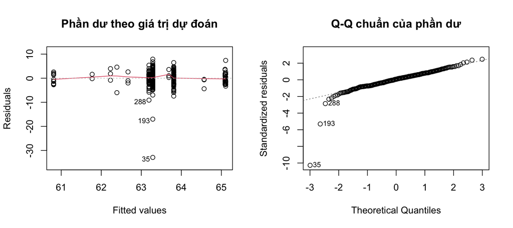

```r
par(mfrow = c(1, 2))
plot(aov_add, which = 1, caption = ""); title("Phần dư theo giá trị dự đoán")
plot(aov_add, which = 2, caption = ""); title("Q-Q chuẩn của phần dư")
```

```r
par(mfrow = c(1, 1))

lev <- car::leveneTest(Hand.Wing.Index ~ Habitat * Habitat.Density, data = anv)
sw_a <- shapiro.test(residuals(aov_add))
cook_a <- cooks.distance(aov_add)
n_cook <- sum(cook_a > 4 / nrow(anv))
kb(tibble::tibble(
  `Giả định / chẩn đoán` = c("Đồng nhất phương sai (Levene)", "Phần dư chuẩn (Shapiro-Wilk)",
                             "Quan sát ảnh hưởng mạnh (Cook > 4/n)"),
  `Kết quả` = c(fmt_p(lev$`Pr(>F)`[1]), fmt_p(sw_a$p.value),
                sprintf("%d / %d", n_cook, nrow(anv)))),
  caption = "Kiểm tra giả định và chẩn đoán ảnh hưởng của mô hình ANOVA cộng tính.")
```

Kiểm tra giả định và chẩn đoán ảnh hưởng của mô hình ANOVA cộng tính.

| Giả định / chẩn đoán | Kết quả |
| --- | --- |
| Đồng nhất phương sai (Levene) | 0.692 |
| Phần dư chuẩn (Shapiro-Wilk) | < 0.001 |
| Quan sát ảnh hưởng mạnh (Cook > 4/n) | 11 / 365 |

**Kiểm tra giả định.**

- Kiểm định Levene có p = 0.692. Giá trị này không cung cấp bằng chứng về khác biệt phương sai, nhưng không chứng minh phương sai bằng nhau: nhiều ô chỉ có 2–3 loài nên kiểm định có công suất thấp. Vì vậy, bảng HC3 ở trên được dùng như kiểm tra robust.
- Kiểm định Shapiro-Wilk cho thấy phần dư không có phân phối chuẩn. HWI lệch trái mạnh (skew = -3.2), chủ yếu do một số loài có HWI thấp bất thường.
- Có 11 quan sát vượt ngưỡng Cook > 4/n. Đây là những quan sát có khả năng ảnh hưởng đáng kể đến kết quả mô hình và cần được lưu ý khi diễn giải.

Do giả định phân phối chuẩn không được đáp ứng tốt, báo cáo thực hiện thêm Kruskal-Wallis. Đây là kiểm tra bổ sung không yêu cầu phân phối chuẩn, nhưng chỉ xét được từng nhân tố riêng lẻ.

```r
kw_h <- kruskal.test(Hand.Wing.Index ~ Habitat, data = anv)
kw_d <- kruskal.test(Hand.Wing.Index ~ Habitat.Density, data = anv)
kb(tibble::tibble(
  `Kiểm định phi tham số` = c("HWI ~ Habitat", "HWI ~ Habitat.Density"),
  `chi-squared` = round(c(kw_h$statistic, kw_d$statistic), 2),
  `p-value` = c(fmt_p(kw_h$p.value), fmt_p(kw_d$p.value))),
  caption = "Kiểm định Kruskal-Wallis (kiểm chứng phi tham số, MỘT nhân tố).")
```

Kiểm định Kruskal-Wallis (kiểm chứng phi tham số, MỘT nhân tố).

| Kiểm định phi tham số | chi-squared | p-value |
| --- | --- | --- |
| HWI ~ Habitat | 21.63 | < 0.001 |
| HWI ~ Habitat.Density | 10.12 | 0.006 |

**Kết quả kiểm tra bổ sung.** Kruskal-Wallis cũng cho thấy HWI có khác biệt theo `Habitat` khi không giả định phân phối chuẩn.

Tuy nhiên, Kruskal-Wallis chỉ xem xét một nhân tố tại một thời điểm. Kiểm định này không điều chỉnh cho nhân tố còn lại và không đánh giá tương tác, nên không thay thế hoàn toàn cho ANOVA hai nhân tố. Đặc biệt, kết quả của `Habitat.Density` (p = 0.006) có thể phản ánh sự liên hệ chặt giữa mật độ và môi trường sống, chứ chưa đủ để kết luận mật độ có ảnh hưởng độc lập.

## 5.2 Ảnh hưởng riêng, tương tác và hậu nghiệm

**Độ lớn của ảnh hưởng.** P-value cho biết dữ liệu có cung cấp bằng chứng về khác biệt hay không, nhưng không cho biết khác biệt đó lớn đến mức nào. Vì vậy, báo cáo tính thêm kích thước hiệu ứng (*effect size*).

```r
eta <- effectsize::eta_squared(car::Anova(aov_add, type = 2), partial = TRUE)
omega <- effectsize::omega_squared(car::Anova(aov_add, type = 2), partial = TRUE)
kb(tibble::tibble(
  `Nhân tố` = eta$Parameter,
  `Partial η²` = round(eta$Eta2_partial, 3),
  `Partial ω²` = round(omega$Omega2_partial, 3)),
  caption = "Độ lớn hiệu ứng của mô hình ANOVA cộng tính.")
```

Độ lớn hiệu ứng của mô hình ANOVA cộng tính.

| Nhân tố | Partial η² | Partial ω² |
| --- | --- | --- |
| Habitat | 0.029 | 0.018 |
| Habitat.Density | 0.008 | 0.002 |

**So sánh từng môi trường sống.** Do tỷ lệ các mức mật độ không giống nhau giữa các môi trường, việc so sánh trực tiếp trung bình thô có thể không công bằng. Báo cáo sử dụng trung bình biên ước lượng (*estimated marginal means*, EMM) để so sánh `Habitat` sau khi đã điều chỉnh cho `Habitat.Density`.

Sau đó, các môi trường được so sánh từng cặp và p-value được hiệu chỉnh Tukey. Bước hiệu chỉnh này hạn chế việc tìm thấy khác biệt chỉ do thực hiện nhiều phép so sánh cùng lúc.

Tuy nhiên, vì một số tổ hợp `Habitat`–`Habitat.Density` không có quan sát, EMM phải dựa vào giả định cộng tính để ước lượng cho những tổ hợp còn thiếu. Do đó, EMM là trung bình được điều chỉnh theo mô hình, không phải trung bình quan sát trực tiếp.

```r
emm <- emmeans::emmeans(aov_add, ~ Habitat)
emm_df <- as.data.frame(emm)
kb(tibble::tibble(
  `Habitat` = emm_df$Habitat,
  `EMM (HWI)` = round(emm_df$emmean, 1),
  `SE` = round(emm_df$SE, 2),
  `KTC 95% dưới` = round(emm_df$lower.CL, 1),
  `KTC 95% trên` = round(emm_df$upper.CL, 1)),
  caption = "Trung bình biên HWI theo Habitat (đã hiệu chỉnh Habitat.Density).")
```

Trung bình biên HWI theo Habitat (đã hiệu chỉnh Habitat.Density).

| Habitat | EMM (HWI) | SE | KTC 95% dưới | KTC 95% trên |
| --- | --- | --- | --- | --- |
| Forest | 63.2 | 0.43 | 62.3 | 64.0 |
| Grassland | 61.6 | 0.99 | 59.6 | 63.5 |
| Human Modified | 64.4 | 0.84 | 62.8 | 66.1 |
| Shrubland | 62.5 | 0.54 | 61.5 | 63.6 |
| Woodland | 64.5 | 0.76 | 63.0 | 66.0 |

```r
pw <- as.data.frame(emmeans::contrast(emm, "pairwise", adjust = "tukey"))
kb(tibble::tibble(
  `Cặp` = pw$contrast,
  `Chênh lệch` = round(pw$estimate, 2),
  `SE` = round(pw$SE, 2),
  `p (Tukey)` = round(pw$p.value, 3)) |> arrange(`p (Tukey)`),
  caption = "So sánh cặp Habitat (emmeans, hiệu chỉnh Tukey).")
```

So sánh cặp Habitat (emmeans, hiệu chỉnh Tukey).

| Cặp | Chênh lệch | SE | p (Tukey) |
| --- | --- | --- | --- |
| Shrubland - Woodland | -1.92 | 0.84 | 0.149 |
| Human Modified - Shrubland | 1.90 | 0.86 | 0.180 |
| Grassland - Woodland | -2.88 | 1.31 | 0.185 |
| Grassland - Human Modified | -2.86 | 1.42 | 0.263 |
| Forest - Woodland | -1.30 | 0.83 | 0.516 |
| Forest - Human Modified | -1.28 | 0.82 | 0.527 |
| Forest - Grassland | 1.58 | 1.25 | 0.711 |
| Forest - Shrubland | 0.62 | 0.55 | 0.793 |
| Grassland - Shrubland | -0.96 | 1.25 | 0.939 |
| Human Modified - Woodland | -0.02 | 1.06 | 1.000 |

```r
# Phân tích độ nhạy: EMM trọng số bằng nhau, trọng số theo tần suất và trung bình thô
emm_prop <- as.data.frame(emmeans::emmeans(aov_add, ~ Habitat,
                                           weights = "proportional"))
raw_hab <- anv |>
  group_by(Habitat) |>
  summarise(`Trung bình thô` = mean(Hand.Wing.Index), .groups = "drop")
sensitivity_emm <- tibble::tibble(
  Habitat = emm_df$Habitat,
  `EMM (trọng số bằng nhau)` = emm_df$emmean,
  `EMM (trọng số tỷ lệ)` = emm_prop$emmean
) |>
  left_join(raw_hab, by = "Habitat") |>
  mutate(across(where(is.numeric), ~ round(.x, 2)))
kb(sensitivity_emm,
   caption = "Phân tích độ nhạy của trung bình HWI theo cách đặt trọng số/điều chỉnh.")
```

Phân tích độ nhạy của trung bình HWI theo cách đặt trọng số/điều chỉnh.

| Habitat | EMM (trọng số bằng nhau) | EMM (trọng số tỷ lệ) | Trung bình thô |
| --- | --- | --- | --- |
| Forest | 63.16 | 63.46 | 63.41 |
| Grassland | 61.58 | 61.88 | 61.11 |
| Human Modified | 64.45 | 64.75 | 65.01 |
| Shrubland | 62.54 | 62.85 | 63.12 |
| Woodland | 64.46 | 64.76 | 64.89 |

**Phân tích độ nhạy.** Báo cáo đặt EMM tính theo hai cách bên cạnh trung bình thô để xem kết quả phụ thuộc bao nhiêu vào cách điều chỉnh. Chênh lệch lớn nhất giữa EMM trọng số bằng nhau và trung bình thô chỉ khoảng 0.58 điểm HWI. Vì vậy, xu hướng mô tả chung không thay đổi nhiều theo cách tính trung bình.

Kết quả này không xóa được hạn chế của dữ liệu. Do một số môi trường gần như không có đủ các mức mật độ, các giá trị điều chỉnh vẫn có phần dựa trên ngoại suy.

**Diễn giải kết quả.**

- `Habitat` có partial η² ≈ 0.029 và partial ω² ≈ 0.018. Các giá trị này cho thấy môi trường sống chỉ giải thích một phần rất nhỏ biến thiên của HWI sau khi đã xét mật độ sinh cảnh.
- Sau khi điều chỉnh cho `Habitat.Density` và hiệu chỉnh Tukey, không cặp môi trường sống nào khác biệt có ý nghĩa thống kê; p-value nhỏ nhất là 0.149.
- Trung bình thô cho thấy Grassland có HWI thấp nhất, còn Woodland và Human Modified cao nhất. Đây chỉ là xu hướng mô tả, chưa phải bằng chứng chắc chắn về khác biệt giữa các cặp.

Việc kiểm định tổng thể của `Habitat` có p-value dưới 0,05 nhưng không cặp riêng nào đạt ý nghĩa sau Tukey không phải là mâu thuẫn. Kiểm định tổng thể hỏi liệu năm nhóm có khác nhau nói chung hay không, còn kiểm định Tukey xét từng cặp và áp dụng ngưỡng chặt hơn vì có nhiều phép so sánh.

**Kết luận.** Dữ liệu gợi ý HWI có khác biệt theo môi trường sống, nhưng bằng chứng chưa mạnh và độ lớn ảnh hưởng nhỏ. Chưa thể xác định chắc chắn cặp môi trường nào khác nhau, cũng chưa thể đánh giá đầy đủ tương tác giữa môi trường sống và mật độ sinh cảnh. Vì dữ liệu mất cân bằng, có ô rỗng và một số nhóm có ít loài, kết quả cần được diễn giải thận trọng.

# 6 So sánh và thảo luận

## 6.1 So sánh các phương pháp hồi quy

```r
kb(tibble::tibble(
  `Tiêu chí` = c("Khả năng dự báo", "Lựa chọn biến", "Xử lý đa cộng tuyến",
                 "Khả năng diễn giải", "Điều kiện áp dụng"),
  `OLS` = c(sprintf("R²≈%.2f; gần Ridge", m_ols["R2"]), "Không; giữ toàn bộ biến",
            "Không xử lý trực tiếp", "Hệ số trực tiếp nhưng thiếu ổn định",
            "Mô hình cơ sở; cần thận trọng khi cộng tuyến cao"),
  `Ridge` = c(sprintf("R²≈%.2f; gần OLS", m_ridge["R2"]), "Không; giữ toàn bộ biến",
              "Co hệ số để giảm ảnh hưởng của cộng tuyến",
              "Hệ số bớt nhạy nhưng bị co về 0", "Phù hợp khi nhiều biến tương quan"),
  `LASSO` = c(sprintf("R²≈%.2f; sai số cao hơn nhẹ", m_lasso["R2"]),
              sprintf("Có; còn %d biến", sum(co[, 1] != 0) - 1),
              "Giảm biến dư thừa nhưng lựa chọn có thể thay đổi",
              "Mô hình gọn, dễ trình bày hơn", "Phù hợp khi cần ít biến"),
  `PCR` = c(sprintf("R²≈%.2f", m_pcr["R2"]),
            sprintf("Giảm còn %d thành phần", k_os),
            "Các thành phần không tương quan", "Diễn giải gián tiếp qua thành phần",
            "Phù hợp khi cần giảm số chiều")),
  caption = "So sánh tổng hợp bốn phương pháp hồi quy.")
```

So sánh tổng hợp bốn phương pháp hồi quy.

| Tiêu chí | OLS | Ridge | LASSO | PCR |
| --- | --- | --- | --- | --- |
| Khả năng dự báo | R²≈0.85; gần Ridge | R²≈0.86; gần OLS | R²≈0.84; sai số cao hơn nhẹ | R²≈0.85 |
| Lựa chọn biến | Không; giữ toàn bộ biến | Không; giữ toàn bộ biến | Có; còn 4 biến | Giảm còn 7 thành phần |
| Xử lý đa cộng tuyến | Không xử lý trực tiếp | Co hệ số để giảm ảnh hưởng của cộng tuyến | Giảm biến dư thừa nhưng lựa chọn có thể thay đổi | Các thành phần không tương quan |
| Khả năng diễn giải | Hệ số trực tiếp nhưng thiếu ổn định | Hệ số bớt nhạy nhưng bị co về 0 | Mô hình gọn, dễ trình bày hơn | Diễn giải gián tiếp qua thành phần |
| Điều kiện áp dụng | Mô hình cơ sở; cần thận trọng khi cộng tuyến cao | Phù hợp khi nhiều biến tương quan | Phù hợp khi cần ít biến | Phù hợp khi cần giảm số chiều |

## 6.2 Kết luận thống kê và ý nghĩa sinh học

### 6.2.1 Câu hỏi 1: Dự đoán khối lượng cơ thể

**Kết quả dự báo.** Các số đo hình thái, cùng biến địa lý bổ sung `logRange`, dự đoán khá tốt khối lượng cơ thể chim ruồi. OLS và Ridge lần lượt đạt $R^2$ = 0.852 và 0.857, với sai số tuyệt đối trung bình khoảng 0.69 g trên tập kiểm định. Khối lượng điển hình trong tập này vào khoảng 5 g.

Trong lần chia hiện tại, OLS chỉ dùng hình thái có RMSE = 0.1596, so với 0.1604 khi thêm `logRange`. Vì vậy, dữ liệu chưa cho thấy `logRange` cải thiện dự báo ngoài các số đo hình thái.

Repeated CV cũng cho thấy OLS và Ridge có sai số gần như bằng nhau. Vì chênh lệch giữa hai mô hình nhỏ hơn nhiều so với mức dao động giữa các lần đánh giá, không có đủ cơ sở để gọi một mô hình là tốt nhất tuyệt đối.

**Ảnh hưởng của đa cộng tuyến.** Nhiều số đo hình thái tương quan rất mạnh, làm hệ số OLS của từng biến thiếu ổn định và khó diễn giải riêng. Tuy nhiên, kết quả trên tập kiểm định và repeated CV cho thấy khả năng dự báo chung của mô hình vẫn tốt. Đây là hai vấn đề khác nhau: mô hình có thể dự báo tốt nhưng chưa chắc xác định chính xác đóng góp riêng của từng biến.

**Chọn mô hình theo mục tiêu.**

- OLS phù hợp làm mô hình cơ sở và cho hệ số trực tiếp, nhưng các hệ số cần được diễn giải thận trọng.
- Ridge phù hợp khi ưu tiên dự báo, muốn giữ toàn bộ biến và giảm ảnh hưởng của đa cộng tuyến.
- LASSO phù hợp khi cần mô hình gọn với 4 biến, chấp nhận sai số cao hơn một chút.
- PCR phù hợp khi muốn tóm tắt dữ liệu bằng 7 thành phần không tương quan, nhưng ý nghĩa của từng thành phần gián tiếp hơn.

**Ý nghĩa sinh học.** PC1 phản ánh xu hướng kích thước hình thái chung và giải thích 52.5% biến thiên của các biến dự báo. Điều này cho thấy các số đo cơ thể thường thay đổi cùng nhau, đồng thời giải thích vì sao đa cộng tuyến xuất hiện mạnh. Kết quả chỉ phản ánh mối liên hệ thống kê, chưa chứng minh đặc điểm hình thái hoặc phạm vi phân bố gây ra thay đổi khối lượng.

### 6.2.2 Câu hỏi 2: HWI và môi trường sống

**Kết quả ANOVA.** `Habitat` có p cổ điển = 0.032 và p robust HC3 = 0.002, cho thấy có liên hệ thăm dò giữa HWI và môi trường sống. Tuy nhiên, thiết kế mất cân bằng và độ lớn ảnh hưởng rất nhỏ (partial η² ≈ 0.029).

Sau khi điều chỉnh cho `Habitat.Density` và hiệu chỉnh Tukey, không cặp môi trường sống nào khác biệt có ý nghĩa; p-value nhỏ nhất là 0.149. Dữ liệu cũng chưa cho thấy ảnh hưởng riêng rõ ràng của mật độ sinh cảnh. Tương tác giữa môi trường và mật độ không thể kiểm tra đầy đủ vì một số tổ hợp không có quan sát.

Grassland có xu hướng HWI thấp hơn trong thống kê mô tả, nhưng dữ liệu hiện tại chưa đủ để khẳng định khác biệt này. Cần thêm quan sát ở các tổ hợp môi trường–mật độ còn thiếu trước khi đưa ra kết luận sinh học chắc chắn hơn.

## 6.3 Hạn chế và hướng cải tiến

- **Đa cộng tuyến và chọn biến:** Có thể thử Elastic Net, phương pháp kết hợp Ridge và LASSO, để chọn biến mà ít phụ thuộc hơn vào việc biến nào được chọn trong một nhóm tương quan.
- **Quan hệ phi tuyến:** Quan hệ giữa các kích thước cơ thể có thể không hoàn toàn là đường thẳng. GAM hoặc mô hình cây như Random Forest và XGBoost có thể được đánh giá thêm bằng cùng quy trình kiểm chứng chéo.
- **Phần dư không chuẩn:** Hồi quy robust hoặc bootstrap có thể giúp việc suy luận hệ số ít nhạy hơn với một số quan sát bất thường.
- **Nguồn trait và khối lượng:** Phân tích chính đã loại các dòng có trait suy diễn hoặc `Mass.Source` là `Inferred`/`EltonTraits_Model`. Khi có thêm dữ liệu đo trực tiếp, cần kiểm tra lại xem kết quả có thay đổi theo nguồn và cỡ mẫu đo hay không.
- **Quan hệ phát sinh loài:** Các loài có họ hàng gần có thể có đặc điểm giống nhau, nên giả định các quan sát độc lập có thể không đúng. Nếu có cây phát sinh loài, PGLS sẽ phù hợp hơn để xử lý cấu trúc này; đánh giá dự báo sang dòng tiến hóa mới cũng nên dùng phylogenetic block cross-validation thay cho chia loài hoàn toàn ngẫu nhiên.
- **Dữ liệu ANOVA còn thiếu tổ hợp:** Giải pháp quan trọng nhất là thu thập thêm loài ở các tổ hợp `Habitat`–`Habitat.Density` đang trống hoặc có rất ít quan sát. Mô hình hỗn hợp chỉ hữu ích khi dữ liệu có thêm cấu trúc nhóm hoặc phân cấp phù hợp; nó không tự khắc phục các ô rỗng.
- **Giới hạn diễn giải:** Đây là dữ liệu quan sát, nên các kết quả mô tả mối liên hệ chứ không chứng minh quan hệ nhân quả.